# Relación del sedentarismo con problemas auditivos y visuales

Jorge Bermejo, Antonia Añazco, Daniel Marrón

2023-11-24

2023-11-28

## INTRODUCCIÓN 📖

El sedentarismo representa un serio problema para la salud pública, especialmente en Occidente, según Rodulfo, J. I. A. (2019) 🤓 [1]. Algunos de sus principales efectos, ampliamente estudiados, se evidencian en trastornos como la hipertensión, la diabetes tipo II o la obesidad, las cuales ya alcanzan la categoría de epidemia en los Estados Unidos según Hu, F. B. (2003) 🤓 [2]. En el mismo artículo se habla también de la relación directa entre estos trastornos y un estilo de vida sedentario, y, en particular, se comenta como un estilo de vida sedentario tiene consecuencias muy negativas independientemente de dieta y cantidad de horas dedicadas a la actividad física.

Ahora bien, ¿alguna vez os habéis planteado cómo afecta al sedentarismo a otros aspectos acerca de nuestra salud no tan obvios?

Carga de los datos a usar:

```r
library(tidyjson)
library(rjson)
library(tidyverse)
```

```r
library(readr)
library(readxl)
library(dplyr)
library(ggplot2)
library(tidyr)

audifono_sexo_edad <- fromJSON(file = "DATOS/audif_SexAge_miles.json")
gafas_sexo_edad <- fromJSON(file = "DATOS/gafas_SexAge_miles.json")
imc_sexo_edad <- fromJSON(file = "DATOS/imc_SexAge_miles.json")
sedentarismo_sexo_edad <- fromJSON(file = "DATOS/seden_SexAge_miles.json")
```

Formateamos los datos:

```r
audif_sexo_edad <- audifono_sexo_edad %>% spread_all()
gafas_sexo_edad <- gafas_sexo_edad %>% spread_all()
imc_sexo_edad <- imc_sexo_edad %>% spread_all()
sedent_sexo_edad <- sedentarismo_sexo_edad %>% spread_all()
```

```r
imc_sexo_edad %>% gather_object %>% json_types %>% count(name,type)
```

```r
imc_SexAge <- imc_sexo_edad %>%
enter_object(Data) %>%
gather_array %>%
spread_all()
imc_SexAge$Sexo <- NA
imc_SexAge$Edad <- NA
imc_SexAge$IMC <- NA
for (i in 1:dim(imc_SexAge)[1]){
  r <- unlist(gregexpr(',', imc_SexAge$Nombre[i]))
  primera_coma <- r[1]
  segunda_coma <- r[2]
  imc_SexAge$Sexo[i] <- substring(imc_SexAge$Nombre[i], 0, primera_coma-1)
  imc_SexAge$Edad[i] <- substring(imc_SexAge$Nombre[i], primera_coma+1, segunda_coma-1)
  imc_SexAge$IMC[i] <- substring(imc_SexAge$Nombre[i], segunda_coma+1)
}
```

Algunas aclaraciones al respecto:

```r
imc_sexo_gredad %>% gather_object %>% json_types %>% count(name,type)
```

Este “Code Chunk” (que no se evalúa) nos sirve para saber a que datos hemos de acceder. Además, las funciones `unlist(gregexpr())` devuelve el índice de todas las apariciones de un determinado character en un character de mayor longitud. La función `substring()` devuelve el sub-character presente en un character de mayor longitud entre ciertos índices pasados como argumento.

```r
audif_sexo_edad %>% gather_object %>% json_types %>% count(name, type)
```

```r
sedent_SexAge <- sedent_sexo_edad %>%
enter_object(Data) %>%
gather_array %>%
spread_all()
sedent_SexAge$Sexo <- NA
sedent_SexAge$Edad <- NA
sedent_SexAge$Sedentarismo <- NA
for (i in 1:dim(sedent_SexAge)[1]){
  r <- unlist(gregexpr(',', sedent_SexAge$Nombre[i]))
  primera_coma <- r[1]
  segunda_coma <- r[2]
  sedent_SexAge$Sexo[i] <- substring(sedent_SexAge$Nombre[i], 0, primera_coma-1)
  sedent_SexAge$Edad[i] <- substring(sedent_SexAge$Nombre[i], primera_coma+1, segunda_coma-1)
  sedent_SexAge$Sedentarismo[i] <- substring(sedent_SexAge$Nombre[i], segunda_coma+1)
}
```

```r
gafas_sexo_edad %>% gather_object %>% json_types %>% count(name,type)
```

```r
gafas_SexAge <- gafas_sexo_edad %>%
  enter_object(Data) %>%
  gather_array %>%
  spread_all()
gafas_SexAge$Sexo <- NA
gafas_SexAge$Edad <- NA
gafas_SexAge$Gafas <- NA
for (i in 1:dim(gafas_SexAge)[1]){
  r <- unlist(gregexpr(',', gafas_SexAge$Nombre[i]))
  primera_coma <- r[1]
  segunda_coma <- r[2]
  gafas_SexAge$Sexo[i] <- substring(gafas_SexAge$Nombre[i], 0, primera_coma-1)
  gafas_SexAge$Edad[i] <- substring(gafas_SexAge$Nombre[i], primera_coma+1, segunda_coma-1)
  gafas_SexAge$Gafas[i] <- substring(gafas_SexAge$Nombre[i], segunda_coma+1)
}
```

```r
audif_sexo_edad %>% gather_object %>% json_types %>% count(name, type)
```

```r
audif_SexAge <- audif_sexo_edad %>%
  enter_object(Data) %>%
  gather_array %>%
  spread_all()
audif_SexAge$Sexo <- NA
audif_SexAge$Edad <- NA
audif_SexAge$Audifono <- NA
for (i in 1:dim(audif_SexAge)[1]){
  r <- unlist(gregexpr(',', audif_SexAge$Nombre[i]))
  primera_coma <- r[1]
  segunda_coma <- r[2]
  audif_SexAge$Sexo[i] <- substring(audif_SexAge$Nombre[i], 0, primera_coma-1)
  audif_SexAge$Edad[i] <- substring(audif_SexAge$Nombre[i], primera_coma+1, segunda_coma-1)
  audif_SexAge$Audifono[i] <- substring(audif_SexAge$Nombre[i], segunda_coma+1)
}
```

```r
sedent_audif <-
  audif_SexAge %>%
  mutate(numero_audifonos = Valor*1000) %>%
  select("Sexo", "Audifono", "numero_audifonos", "Edad") %>%
  full_join(x = .,
            y = sedent_SexAge %>%
            mutate(personas_sedentarias = Valor*1000) %>%
            select("Sexo", "Sedentarismo", "personas_sedentarias", "Edad"),
            by = c("Sexo" = "Sexo", "Edad" = "Edad"))
```

Básicamente, en estos dos bloques de código lo que hacemos es, primeramente, unir los conjuntos de datos acerca de uso de audífonos y de sedentarismo. Para ello, primeramente, mutamos ambos conjuntos de datos y seleccionamos aquellos atributos de nuestro interés. Para, como se ha indicado, llevar a cabo dicha mutación, multiplicamos por mil, porque, tras revisar los conjuntos de datos (en particular hemos necesitado abrir los datos para ver las unidades en las que se encuentran, mal ahí, datos.gov 😡) vimos que se encontraban en miles de personas.

Posteriormente, unimos por sexo y edad (dado que los niveles de ambas variables son los mismos) (hay que aclarar que la edad, a priori, habría de ser una variable continua, pero es categórica al haber sido discretizada). A la hora de representar los datos, primero modificamos debidamente el conjunto de resultados hasta obtener uno que se amolda a los objetivos que pretendemos estudiar.

Finalmente, antes de crear la gráfica de barras, creamos una variable que relacione la cantidad de audífonos con el número de personas. Esto se debe a que son severamente desiguales las cantidades de personas que son y no sedentarias y que usan y no audífonos.

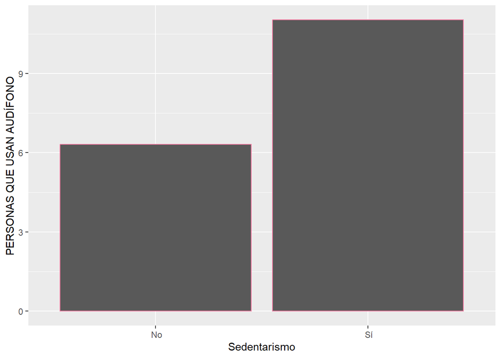

```r
sedent_audif %>% filter(Sexo == "Ambos sexos") %>%
  filter(Audifono == " Sí") %>%
  filter(Sedentarismo %in% c(" Sí", " No")) %>%
  mutate(ratio_audifonos_por_persona = 100*numero_audifonos/personas_sedentarias) %>%
  filter(Edad == " TOTAL") %>%
  ggplot(data = .,aes(x = Sedentarismo , y = ratio_audifonos_por_persona)) +
  xlab("Sedentarismo") +
  ylab("PERSONAS QUE USAN AUDÍFONO") +
  geom_col(colour = "palevioletred2")
```

## BIBLIOGRAFÍA 📖

[1] Rodulfo, J. I. A. (2019). Sedentarism, a disease from XXI century. Clínica e Investigación en arteriosclerosis (English edition), 31(5), 233-240. https://doi.org/10.1016/j.artere.2019.04.001

[2] Hu, F. B. (2003). Sedentary lifestyle and risk of obesity and type 2 diabetes. Lipids, 38(2), 103-108.